# Task 1: Abundance Exploration of Sierra Amphibians

Samantha Kuglen

1/22/2022

### A. Overview

This report provides an exploratory review of amphibian abundance data in the Sierra Lakes recorded from 1995 - 2002. The purpose of this analysis is to wrangle and visualize counts for mountain yellow-legged frogs (*Rana muscosa*). This data is important because it has supported research and management of Sierra Nevada aquatic ecosystems and their terrestrial interfaces.

### B. Data and Analysis

This amphibian data contains observations physical characteristics of and surveyed aquatic communities for >8,000 lentic water bodies in the southern Sierra Nevada, including lakes, ponds, marshes, and meadows. The data was collected and made available by the [Sierra Lakes Inventory Project (SLIP)](https://portal.edirepository.org/nis/mapbrowse?packageid=edi.577.2). All analyses are in R version 4.0.2 using RStudio version 1.3.1056.

```r
knitr::opts_chunk$set(echo = TRUE, message = FALSE, warning = FALSE)

# Attach packages
library(tidyverse)
library(here)
library(lubridate)
library(patchwork)
library(paletteer)
```

```r
# Read in the data
amphibian_data <- read_csv(here("data", "sierra_amphibians.csv"))
```

### Data Wrangling and Visualization I

Find total number of adult, subadult, and tadpole mountain yellow-legged frogs observed in the entire study by life stage and year, excluding Eggmass level, then store results for visualization.

```r
# Filter for *Rana muscosa* species only, exclude EggMass and use `lubridate` package to retrieve year for grouping
total_yellow_frogs <- amphibian_data %>%
  filter(amphibian_species == "RAMU", amphibian_life_stage != "EggMass") %>%
  mutate(survey_date = mdy(survey_date), year = year(survey_date))

# Create a table to verify the counts that will be depicted in final plot
frogs_count <- total_yellow_frogs %>%
  group_by(year, amphibian_life_stage) %>%
  summarize(amphib_count = n())

# Visualize total counts across all water bodies, grouping by amphibian_life_stage
plot1 <- ggplot(data = total_yellow_frogs,
                aes(x = year, group = amphibian_life_stage, fill = amphibian_life_stage)) +
  geom_bar(position = "dodge") + # separates counts
  labs(title = "Total Mountain Yellow-Legged Frogs Per Year",
       subtitle = "Sierra Lakes (1995 - 2002)",
       x = "Year",
       y = "Count",
       fill = "Amphibian Life Stage") +
  theme_linedraw() +
  theme(plot.title = element_text(hjust = 0.5, face = "bold"), # center title/subtitle
        plot.subtitle = element_text(hjust = 0.5),
        plot.background = element_rect(fill = "#D3D3D3"),
        legend.key = element_rect(fill = "black"),
        legend.background = element_rect(fill = "#f5ebeb")) +
  scale_x_continuous(breaks = c(1995:2002)) + # add breaks to show all years
  scale_fill_paletteer_d(palette = "colorBlindness::Blue2Gray8Steps") + # colorblind-friendly palette
  scale_alpha(guide = "none") # suppress duplicate legend
```

### Data Wrangling and Visualization II

```r
top_5_lakes <- total_yellow_frogs %>%
  filter(amphibian_life_stage != "Tadpole") %>%
  group_by(lake_id) %>%
  summarize(total = sum(amphibian_number)) %>%
  slice_max(order_by = total, n = 5)

#as.character change to read as a string because the ID is a number

top_5_lakes$lake_id <- sapply(top_5_lakes$lake_id, function(x) paste("Lake", x))
top_5_lakes$lake_id <- fct_reorder(as.character(top_5_lakes$lake_id), top_5_lakes$total)

plot2 <- ggplot(data = top_5_lakes, aes(y = lake_id, x = total), aes(fill = total)) +
  geom_col(aes(fill = lake_id)) +
  labs(title = "Lakes With Greatest Adult and SubAdult Yellow-Legged Frogs",
       subtitle = "Sierra Lakes (1995 - 2002)",
       x = "Total Count",
       y = "Lake ID") +
  theme_linedraw() +
  theme(plot.title = element_text(hjust = 0.5, face = "bold"), # center title/subtitle
        plot.subtitle = element_text(hjust = 0.5),
        plot.background = element_rect(fill = "#D3D3D3"),
        axis.title.y = element_text(margin = margin(r = 20)), # add space btwn y-axis label and graph
        legend.position = 'none')  + # hide legend (unnecessary)
    scale_fill_paletteer_d(palette = "colorBlindness::Green2Magenta16Steps") # colorblind-friendly palette
```

### C. Final Data Visualization

Combine plots into a single compound figure

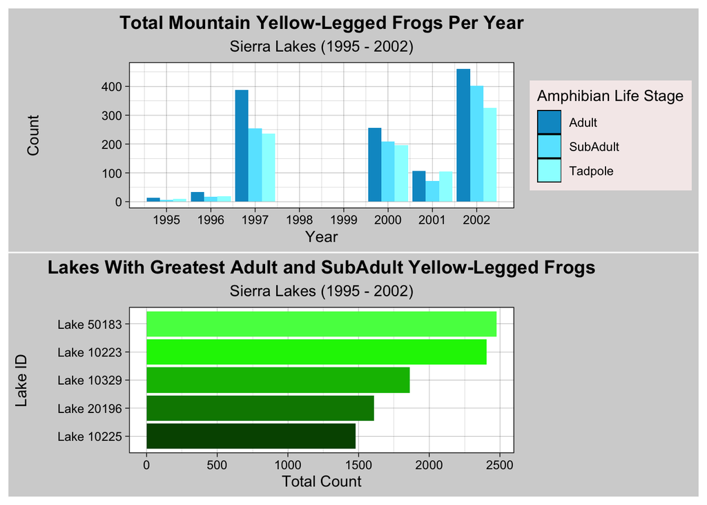

```r
# Use `patchwork` package syntax to place graphs on top of each other
plot1 / plot2
```

**Figure 1.** Counts and distributions of mountain yellow-legged frogs in the Sierra Lakes (*Rana muscosa*) from 1995 to 2002. Top: Counts of mountain yellow-legged frogs each year over all lakes, separated by amphibian life stage. Bottom: 5 Sierra Lakes with the greatest adult and sub-adult frog counts. Data: Knapp et al. (SLIP 2020).

### Data Citation

Knapp, R.A., C. Pavelka, E.E. Hegeman, and T.C. Smith. 2020. The Sierra Lakes Inventory Project: Non-Native fish and community composition of lakes and ponds in the Sierra Nevada, California ver 2. Environmental Data Initiative. https://doi.org/10.6073/pasta/d835832d7fd00d9e4466e44eea87fab3